# Processos relacionados à Arbitragem

Um levantamento no banco de sentenças do TJSP

Autor

Associação Brasileira de Jurimetria

Data de Publicação

29 de setembro de 2023

# Introdução

O Observatório da Arbitragem é um projeto que visa a compreender o fenômeno jurídico da arbitragem nos tribunais estaduais. Em sua primeira fase, o projeto busca compreender o fluxo dos processos de i) anulação de decisão arbitral, ii) cumprimento de sentença / execução, iii) medida cautelar antecedente à constituição do tribunal arbitral, iv) existência, validade e eficácia da convenção de arbitragem e v) ação para instituição da arbitragem com base no art, 7º da Lei de Arbitragem.

O objetivo do levantamento é realizar uma análise preliminar a partir do banco de sentenças do Tribunal de Justiça de São Paulo (TJSP). O levantamento tem como resultado algumas estatísticas básicas como volume de sentenças ao longo do tempo, proporção de decisões favoráveis ao autor e tempo mediano dos processos. O estudo pode ser utilizado como insumo para decidir sobre a viabilidade de uma pesquisa mais aprofundada – envolvendo análise de autos processuais – a partir dos dados disponibilizados no banco de sentenças.

O presente levantamento descreve o fluxo de download, arrumação e análise dos dados de sentenças relacionadas à arbitragem. Na parte de download, descrevemos os termos utilizados para consulta e o procedimento de acesso aos dados, que são públicos, mas não são abertos. A parte de arrumação descreve todos os passos para chegar da base bruta até a base organizada, informando as colunas utilizadas. A análise mostra os resultados do levantamento, com estatísticas sobre o perfil dos processos, o volume de sentenças ao longo do tempo, a proporção de decisões favoráveis e o tempo médio das ações.

# Download

Antes de descrever o processo de coleta, é importante ressaltar que o TJSP não forneceu acesso aos processos mantidos sob sigilo, nem forneceu uma lista de processos distribuídos no período. O pedido de dados foi realizado ainda em 2021 e reiterado por diversas vezes.

Em 30 de maio de 2023, seis meses depois da finalização da coleta dos dados, o TJSP enviou um link para acesso à lista. Infelizmente, no entanto, os dados não puderam ser acessados, pois o link não funcionava. Em resumo, mesmo após muitas tentativas de contato, não foi possível acessar os dados através de ofícios enviados ao TJSP.

Como consequência, a pesquisa recorreu ao banco de sentenças públicas, o que implicou a obtenção de uma amostra que não abarca a totalidade dos processos existentes no TJSP. Apesar desta limitação, acredita-se que os dados coletados e analisados ainda são valiosos e oferecem resultados significativos sobre o tema. Além de uma quantidade significativa de casos ser pública, as sentenças analisadas apareceram em quantidades muito próximas nas duas principais varas especializadas, indicando um grau de aleatorização.

É importante, no entanto, levar essa limitação quanto à quantidade de sentenças em consideração ao interpretar os resultados apresentados, quantidade que pode ser duas ou três vezes menor do que o total geral, tanto quanto acautelar-se ao generalizar interpretações ou conclusões a partir dos números. Nenhum resultado expressado deve ser interpretado como indicativo tendencial de uma maior ou menor possibilidade de êxito, em abstrato, quanto às categorias de processos analisados.

Feitas essas ressalvas, passa-se à metodologia de pesquisa.

Os dados de processos do TJSP são públicos, mas não são abertos. Isso significa que não há meio fácil de obter uma lista de todos os processos que existem no tribunal a partir de um critério jurídico, geográfico ou temporal.

O TJSP, entretanto, disponibiliza ferramentas de consulta. Na [Consulta de Julgados do Primeiro Grau (CJPG)](https://esaj.tjsp.jus.br/cjpg/pesquisar.do) é possível acessar, manualmente, a lista de processos a partir de termos de busca (como palavras-chave, classes e assuntos). Cada processo, por sua vez, pode ser pesquisado manualmente em uma consulta de processos [Consulta de Processos do Primeiro Grau](https://esaj.tjsp.jus.br/cpopg/open.do).

Por conta da necessidade de realizar pesquisas no direito, a ABJ desenvolveu, ao longo de sua história, algumas ferramentas que automatizam o fluxo manual de obtenção de dados. Essas ferramentas utilizam técnicas de raspagem de dados (Zhao 2017) que, em poucas palavras, envolvem imitar o que um ser humano faria para acessar as páginas, mas de forma automática. Vale ressaltar que essa não é uma estratégia oficial nem desejável de ser utilizada ao acessar dados públicos. No entanto, por conta das limitações do tribunal, utilizar raspagem de dados acaba sendo necessário para tornar as pesquisas viáveis.

Ao acessar os dados via raspagem do CJPG, a primeira limitação que aparece são os campos disponíveis. Processos de arbitragem podem aparecer com classes e assuntos processuais[^1] que não identificam corretamente os casos. Por exemplo, é comum encontrar como classe “procedimento ordinário” ou como assunto “anulação”. Por isso, a única forma de listar os processos relacionados à arbitragem é através das palavras-chave.

A desvantagem em utilizar palavras-chave é que as pesquisas se limitam ao que as ferramentas de pesquisa disponibilizam. Se a ferramenta de busca é falha, o resultado é falho. De qualquer forma, por falta de outros meios, essa foi a decisão tomada para acessar os processos relacionados à arbitragem.

O termo de busca utilizado para realizar a pesquisa foi `"arbitral" OU "lei de arbitragem" OU "9307" OU "9.307"`. A ideia da pesquisa foi realizar a busca mais genérica possível relacionada à arbitragem, sem incluir o termo “arbitragem”, já que este aparece no nome das varas, o que implicaria uma lista com todos os processos da vara.

Outro filtro realizado foi o das varas. Foram consideradas 4 varas no total: 1ª vara empresarial e conflitos de arbitragem, 2ª vara empresarial e conflitos de arbitragem, 1ª vara regional de competência empresarial e de conflitos relacionados à arbitragem e 2ª vara regional de competência empresarial e de conflitos relacionados à arbitragem.

Neste ponto, algumas ressalvas devem ser apresentadas sobre o volume total de ações.

Por envolver casos que potencialmente correm em segredo de justiça, é possível que uma parte dos casos não seja acessível por meio do banco de sentenças. Além disso, por envolver apenas as varas empresariais, o recorte pode apresentar limitações de espaço (regiões) e tempo (criação das varas)[^2]. Por último, por se tratar de um estudo retrospectivo (envolve apenas casos com sentença), casos ativos não sentenciados ficaram fora da lista, que pode não detectar tendências ou mudanças mais recentes no perfil desses conflitos.

De qualquer forma, espera-se que a lista obtida, depois de limpa, possa ser utilizada como amostra aleatória da população de todos os processos relacionados à arbitragem.

# Arrumação

O primeiro passo da arrumação dos dados foi a classificação das categorias de processos e remoção de casos que não fazem parte do escopo. Para classificar as cinco categorias, foram utilizados os termos e expressões regulares da Tabela 1.

Tabela 1: Expressões regulares utilizadas para classificar a categoria de ação

| Categoria | Expressões regulares |
| --- | --- |
| Instauracao | (instauracao) |
| Cumprimento | (cumprimento) |
| Convencao | (convenção arbitral) |
| Cautelar | (cautelar OU antecipada) |
| Anulacao | (anulacao OU nulidade) |

A Tabela 2 mostra a quantidade de processos detectada em cada categoria. É importante destacar que toda classificação automática pode incorrer em erros, ou seja, pode ser que as categorias finais fiquem incorretas. Os casos vazios foram retirados.

Tabela 2: Processos classificados por categoria

| Resultado | N | % |
| --- | --- | --- |
| Convencao | 135 | 39.9% |
| Cumprimento | 83 | 24.6% |
| Instauracao | 44 | 13.0% |
| Cautelar | 35 | 10.4% |
| Anulacao | 34 | 10.1% |
| (Vazio) | 7 | 2.1% |
| Total | 338 | 100.0% |

O passo seguinte foi a obtenção dos resultados dos processos. Para classificar as categorias de resultados, foram utilizados os termos e expressões regulares da Tabela 3.

Tabela 3: Expressões regulares utilizadas para classificar o resultado

| Categoria | Expressões regulares |
| --- | --- |
| Acordo | (homologo o acordo) |
| Extinto | (julgo extinto OU julgo extinta OU determino a extincao OU determinar a extincao) |
| Improcedente | (julgo improcedente OU indefiro a tutela) |
| Parcial | (julgo procedente em parte OU parcialmente procedente OU defiro parcialmente a tutela) |
| Procedente | (julgo (o pedido )?procedente OU homologo OU defiro a tutela) |

Por último, as colunas importantes de análise foram construídas. As colunas escolhidas foram: status (em andamento, extinto, em grau de recurso ou suspenso), classe, assunto, valor da causa, processo digital, data de disponibilização da sentença, vara, resultado e tempo (calculado pelo tempo entre a data de distribuição e data da disponibilização da decisão).

## Revisão manual

A base de dados arrumada foi revisada manualmente a partir da leitura dos textos das decisões e outras características dos processos. A revisão foi realizada por profissionais do direito especializados no tema de arbitragem.

A primeira mudança significativa foi com relação aos casos que fazem parte do escopo. Dos 338 casos iniciais, sobraram 289 que faziam parte do escopo[^3].

Com relação às colunas da base, as principais informações alteradas foram as de categoria e resultado. A informação de categoria foi a que mais sofreu alterações, especialmente em ações de anulação de decisão arbitral, que ficaram maiores. A Tabela 4 mostra as classificações depois da correção manual.

Tabela 4: Processos classificados por categoria, após revisão

| Resultado | N | % |
| --- | --- | --- |
| Anulacao | 95 | 32.9% |
| Cumprimento | 75 | 26.0% |
| Cautelar | 63 | 21.8% |
| Convencao | 46 | 15.9% |
| Instauracao | 10 | 3.5% |
| Total | 289 | 100.0% |

Com relação aos resultados, não houve mudanças significativas. A categoria que mais mudou foi a de acordos, que costumam ser difíceis de mapear apenas por palavras-chave. Os resultados completos são apresentados na próxima seção.

Por último, três colunas foram adicionadas após a classificação manual. A primeira é com relação à concessão de liminar em casos de medida cautelar. A segunda decorreu do fato de, na revisão manual, vários casos relacionados à Unimed terem sido detectados. Assim, uma coluna `unimed` foi adicionada para permitir novos filtros de análise. A terceira é a câmara arbitral de origem do processo.

No final, a base ficou com 289 linhas e 14 colunas, contendo todas as informações utilizadas na parte de análise. A base de dados em Excel pode ser baixada [neste link](https://github.com/abjur/obsArb/raw/main/inst/da_arbitragem.xlsx).

## Segunda instância

Depois de baixar e revisar as sentenças, procuraram-se os números de processos obtidos na segunda instância. Foram considerados casos com apenas um recurso (agravo de instrumento ou apelação). Por exemplo, processos que tiveram mais de um agravo de instrumento foram desconsiderados.

Dos 289 processos, 173 apresentaram algum recurso, sendo 126 (73%) com classe “Apelação Cível” e 47 (27%) com classe “Agravo de Instrumento”. Nessa base, somente 132 (76%) possuem alguma decisão, sendo 98 apelações e 34 agravos. Os demais recursos não apresentavam uma tabela de decisões na consulta processual. Além da informação da decisão, também foi coletada a informação do status dos processos no momento da coleta. Essa informação foi extraída diretamente da consulta processual do TJSP, sem nenhum tratamento posterior.

Após o filtro inicial, a base passou por uma revisão manual. A revisão foi realizada nos 57 casos que tinham alguma decisão diferente de não provimento. Na nova análise, foram incluídas duas informações manualmente: se a decisão arbitral foi reformada e uma coluna identificando se o caso era relacionado com a Unimed.

A base de segunda instância foi considerada para calcular a taxa de recorribilidade e a taxa de decisões favoráveis na segunda instância. A taxa de reforma da decisão arbitral foi calculada a partir da análise manual.

A base considerada possui 173 linhas e 8 colunas. A base de dados em Excel pode ser baixada [neste link](https://github.com/abjur/obsArb/raw/main/inst/da_cposg_tidy.xlsx).

# Análise

Esta seção foi organizada em três subseções: análise geral, análise sobre contratos em geral e uma análise específica sobre contratos de colaboração. Para os fins desta pesquisa, adota-se o conceito de contratos de colaboração para aqueles contratos não societários que têm por objetivo balizar a relação entre as partes em termos mais amplos ao longo do tempo, com áleas distintas, mas interdependentes, sem configurar uma sociedade propriamente dita, conforme ensina a Profa. Paula Forgioni[^4]. Os contratos de colaboração identificados nesta pesquisa são aqueles: (i) do sistema arbitral Unimed (58 casos), (ii) envolvendo franquias (13 casos) e (iii) envolvendo associação entre concessionárias e montadoras de veículos automotores (1 caso). Os casos de contratos em geral são todos os demais. Essa segregação foi possível porque os relatórios das decisões judiciais contêm uma descrição da natureza dos contratos sub judice e sua qualificação, o que permite a separação. A razão para a separação entre contratos em geral e contratos de colaboração é a maior propensão destes últimos, pelas suas características, à judicialização da arbitragem em razão de certas peculiaridades envolvendo o consentimento e a autonomia das partes, marcados pela subordinação de uma parte à outra e, assim, por assimetria em dose mais relevante[^5] (o que, não raro, se instrumentaliza pela celebração de contratos por adesão, p. ex., ou por contratos com dependência econômica, que constituem categoria intermédia entre os paritários e os por adesão[^6]). Isso torna útil que, ao lado da análise geral, sejam apresentados também os dados segregados para esses dois grupos de contratos, a fim de permitir inferências específicas e aderentes à realidade própria de cada um desses grupos.

Os casos de contratos de colaboração são definidos com o seguintes critérios: i) casos da Unimed (58 casos), ii) casos envolvendo franquia (13 casos) e iii) casos com origem na câmara da AssoHonda (1 caso). Os casos de contratos em geral são os demais.

Em todas as subseções, foram incluídas estatísticas descritivas como: tabelas com classe, assunto, faixas de valores, quantidade de processos por câmara arbitral, distribuição entre as duas varas, tempo médio / mediano, volume de decisões ao longo do tempo por categoria. As subseções de contratos em geral e de colaboração receberam análises adicionais.

## Análise geral

Em seguida, são apresentadas tabelas das classes e assuntos mais comuns nos processos encontrados. É importante destacar que classes e assuntos nem sempre identificam corretamente o tipo de ação, tanto por motivos de taxonomia (o tipo de processo não existe na classificação do CNJ) quanto por motivos de má classificação (a pessoa que protocolou a ação colocou uma classe/assunto inadequada). Por isso, a classe e assunto não está sendo usada para classificar os tipos de processo.

A Tabela 5 mostra as classes processuais mais comuns encontradas. É possível notar que existem muitas classes que não são relacionadas diretamente à arbitragem.

Tabela 5: Classes mais comuns

| Classe | N | % |
| --- | --- | --- |
| Convenção Arbitral | 77 | 26.6% |
| Procedimento Comum Cível | 64 | 22.1% |
| Cumprimento de sentença - Lei Arbitral (Lei 9.307/1996) | 54 | 18.7% |
| Tutela Cautelar Antecedente | 42 | 14.5% |
| Cumprimento de sentença | 22 | 7.6% |
| Tutela Antecipada Antecedente | 16 | 5.5% |
| Produção Antecipada da Prova | 7 | 2.4% |
| Dissolução Parcial de Sociedade | 4 | 1.4% |
| Embargos à Execução | 2 | 0.7% |
| Interpelação | 1 | 0.3% |
| Total | 289 | 100.0% |

A Tabela 6 mostra os dez assuntos processuais mais comuns encontrados. Assim como nas classes, é possível notar que existem muitos assuntos que não são relacionados diretamente à arbitragem.

Tabela 6: Assuntos mais comuns

| Assunto | N | % |
| --- | --- | --- |
| Defeito, nulidade ou anulação | 92 | 31.8% |
| Sentença arbitral (artigo 515, inciso VII, CPC) | 60 | 20.8% |
| Liminar | 45 | 15.6% |
| Outros | 42 | 14.5% |
| Franquia | 13 | 4.5% |
| Medida cautelar ou de urgência pré-arbitral (Art. 22-A, Lei nº 9.307/96) | 13 | 4.5% |
| Constrição / Penhora / Avaliação / Indisponibilidade de Bens | 6 | 2.1% |
| Obrigação de Fazer / Não Fazer | 5 | 1.7% |
| Valor da Execução / Cálculo / Atualização | 5 | 1.7% |
| Obrigações | 4 | 1.4% |
| Provas em geral | 4 | 1.4% |
| Total | 289 | 100.0% |

A Tabela 7 mostra a contagem de processos por faixa de valores de causa. É possível notar que existe uma alta assimetria, já que há vários processos de até 10 mil reais, mas também processos de mais de 10 milhões de reais.

Tabela 7: Faixas de valores

| Faixa | N | % |
| --- | --- | --- |
| Até R$ 10.000 | 102 | 35.3% |
| Entre R$ 10.000 e R$ 100.000 | 63 | 21.8% |
| Entre R$ 100.000 e R$ 1 milhão | 74 | 25.6% |
| Entre R$ 1 milhão e R$ 10 milhões | 28 | 9.7% |
| R$ 10 milhões ou mais | 21 | 7.3% |
| (Vazio) | 1 | 0.3% |
| Total | 289 | 100.0% |

A Tabela 8 mostra a contagem de processos por vara. As varas empresariais do foro central cível concentram a maior parte dos casos. Por conta do pequeno número de informações, as análises de contagem de resultados e categorias por vara desconsideram as Regiões Administrativas Judiciárias (RAJs).

Tabela 8: Quantidade de processos por vara

| Vara | N | % |
| --- | --- | --- |
| 1ª Vara Empresarial e Conflitos de Arbitragem | 140 | 48.4% |
| 2ª Vara Empresarial e Conflitos de Arbitragem | 137 | 47.4% |
| 1ª Vara Regional de Competência Empresarial e de Conflitos Relacionados à Arbitragem | 6 | 2.1% |
| 2ª Vara Regional de Competência Empresarial e de Conflitos Relacionados à Arbitragem | 6 | 2.1% |
| Total | 289 | 100.0% |

A Figura 1 mostra o volume de decisões ao longo do tempo, separando por categoria de caso. Com exceção das ações de Anulação, é possível observar um crescimento de casos nos anos de 2021 e 2022.

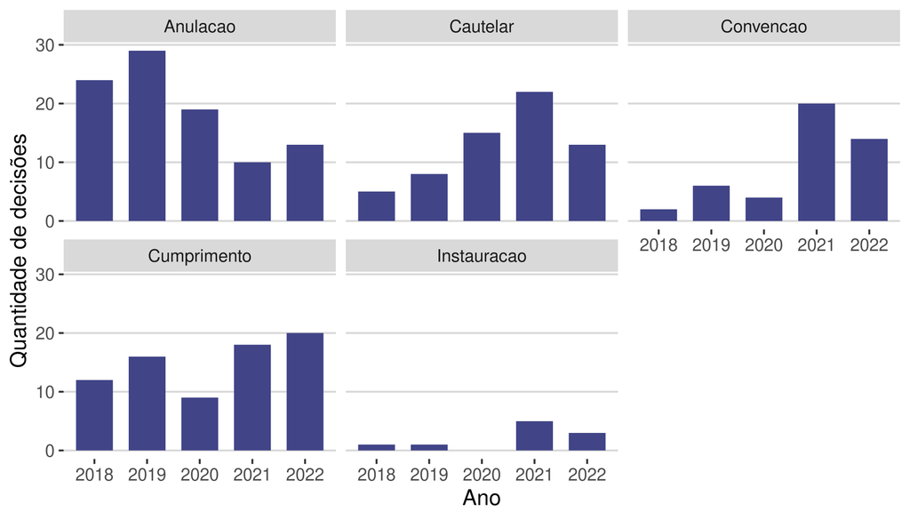

Figura 1: Quantidade de decisões por ano e categoria

A Tabela 9 mostra os tempos médios e medianos, geral e por categoria, em dias. Os processos mais longos são os de convenção arbitral, com mediana de quase um ano. Já os processos mais curtos são os de anulação, com mediana de aproximadamente seis meses.

Tabela 9: Estatísticas descritivas dos tempos dos processos em dias

| Categoria | N | Média | Mediana |
| --- | --- | --- | --- |
| Convencao | 46 | 353.6 | 328.5 |
| Instauracao | 10 | 462.7 | 301.0 |
| Cumprimento | 75 | 306.5 | 251.0 |
| Cautelar | 63 | 232.7 | 194.0 |
| Anulacao | 95 | 274.6 | 188.0 |
| Total | 289 | 292.8 | 227.0 |

Em seguida, apresentam-se comparações entre a quantidade de sentenças arbitrais e a quantidade de anulatórias.

Os dados de sentenças arbitrais foram levantados pela Dra Vera Cecília Monteiro de Barros e gentilmente fornecidos à equipe de pesquisa. Os dados revelam um total de 606 sentenças arbitrais proferidas em arbitragens com sede em São Paulo administradas pelas principais câmaras de arbitragem no mesmo período que os dados levantados no TJSP.

A Tabela 10 compara a quantidade de sentenças arbitrais proferidas em arbitragens com sede em São Paulo nesse conjunto de câmaras e de ações anulatórias encontradas, tendo por objeto sentenças proferidas nessas mesmas câmaras. A taxa geral de anulatórias foi de 2.8%.

Tabela 10: Comparação entre quantidade de decisões arbitrais e ações anulatórias

| Sigla | Câmara | Sentenças arbitrais | Ações anulatórias | Taxa de judicialização |
| --- | --- | --- | --- | --- |
| CCBC | Centro de Arbitragem e Mediação da Câmara de Comércio Brasil-Canadá CAM-CCBC | 223 | 9 | 4.0% |
| FIESP | Câmara de Conciliação, Mediação e Arbitragem CIESP/FIESP | 133 | 4 | 3.0% |
| CAM | Câmara de Arbitragem do Mercado | 64 | 2 | 3.1% |
| FGV | Câmara FGV de Mediação e Arbitragem | 54 | 0 | 0.0% |
| CCI | Corte Internacional de Arbitragem da Câmara de Comércio Internacional - CCI | 47 | 1 | 2.1% |
| CAMARB | Câmara de Mediação e Arbitragem Empresarial | 45 | 0 | 0.0% |
| AMCHAM | Centro de Arbitragem e Mediação AMCHAM | 38 | 0 | 0.0% |
| CBMA | Centro Brasileiro de Mediação e Arbitragem CBMA | 2 | 1 | 50.0% |
| Total | - | 606 | 17 | 2.8% |

Antes de seguir com as comparações, cabe um detalhamento das limitações do estudo. Primeiro, as contagens disponíveis na base de sentenças arbitrais e na base de processos judiciais não correspondem sempre aos mesmos conflitos, já que sempre decorre um tempo entre a sentença arbitral e a sentença do processo judicial. Segundo, como não foram analisados casos que estão em segredo de justiça, a taxa de judicialização, ou seja, a razão entre a quantidade de processos judiciais e a quantidade de sentenças arbitrais está subestimada. Por último, não existem informações da quantidade de sentenças para todas as câmaras arbitrais possíveis, então as análises que comparam as contagens consideram somente as câmaras que têm informação.

## Contratos em Geral

A Tabela 11 mostra as classes processuais mais comuns encontradas. A classe mais comum é o cumprimento de sentença relacionado à Lei de Arbitragem, seguido pelo procedimento comum cível.

Tabela 11: Classes mais comuns

| Classe | N | % |
| --- | --- | --- |
| Cumprimento de sentença - Lei Arbitral (Lei 9.307/1996) | 53 | 24.4% |
| Procedimento Comum Cível | 47 | 21.7% |
| Tutela Cautelar Antecedente | 42 | 19.4% |
| Convenção Arbitral | 23 | 10.6% |
| Cumprimento de sentença | 22 | 10.1% |
| Tutela Antecipada Antecedente | 16 | 7.4% |
| Produção Antecipada da Prova | 7 | 3.2% |
| Dissolução Parcial de Sociedade | 4 | 1.8% |
| Embargos à Execução | 2 | 0.9% |
| Interpelação | 1 | 0.5% |
| Total | 217 | 100.0% |

A Tabela 12 mostra os dez assuntos processuais mais comuns encontrados. O assunto mais comum é a sentença arbitral, seguido pela liminar.

Tabela 12: Assuntos mais comuns

| Assunto | N | % |
| --- | --- | --- |
| Sentença arbitral (artigo 515, inciso VII, CPC) | 60 | 27.6% |
| Liminar | 45 | 20.7% |
| Defeito, nulidade ou anulação | 33 | 15.2% |
| Outros | 33 | 15.2% |
| Medida cautelar ou de urgência pré-arbitral (Art. 22-A, Lei nº 9.307/96) | 13 | 6.0% |
| Constrição / Penhora / Avaliação / Indisponibilidade de Bens | 6 | 2.8% |
| Obrigação de Fazer / Não Fazer | 5 | 2.3% |
| Valor da Execução / Cálculo / Atualização | 5 | 2.3% |
| Obrigações | 4 | 1.8% |
| Provas em geral | 4 | 1.8% |
| Anulação de sentença arbitral (Art. 33, Lei nº 9.307/96) | 3 | 1.4% |
| Dissolução | 3 | 1.4% |
| Ingresso e Exclusão dos Sócios na Sociedade | 3 | 1.4% |
| Total | 217 | 100.0% |

A Tabela 13 mostra a contagem de processos por faixa de valores de causa. Assim como na análise anterior, existe uma alta assimetria, já que existem vários processos de até 10 mil reais, mas também processos de mais de 10 milhões de reais.

Tabela 13: Faixas de valores

| Faixa | N | % |
| --- | --- | --- |
| Até R$ 10.000 | 97 | 44.7% |
| Entre R$ 10.000 e R$ 100.000 | 50 | 23.0% |
| Entre R$ 100.000 e R$ 1 milhão | 36 | 16.6% |
| Entre R$ 1 milhão e R$ 10 milhões | 16 | 7.4% |
| R$ 10 milhões ou mais | 17 | 7.8% |
| (Vazio) | 1 | 0.5% |
| Total | 217 | 100.0% |

A Tabela 14 mostra a contagem de processos por faixa de valores de causa nas anulatórias em contratos em geral. Mais da metade dos processos estão na faixa de até 100 mil reais.

Tabela 14: Faixas de valores nas anulatórias

| Faixa | N | % |
| --- | --- | --- |
| Até R$ 10.000 | 12 | 34.3% |
| Entre R$ 10.000 e R$ 100.000 | 7 | 20.0% |
| Entre R$ 100.000 e R$ 1 milhão | 7 | 20.0% |
| Entre R$ 1 milhão e R$ 10 milhões | 4 | 11.4% |
| R$ 10 milhões ou mais | 5 | 14.3% |
| Total | 35 | 100.0% |

A Tabela 15 mostra a contagem de processos por vara. A proporção é similar ao encontrado na Tabela 8.

Tabela 15: Quantidade de processos por vara

| Vara | N | % |
| --- | --- | --- |
| 1ª Vara Empresarial e Conflitos de Arbitragem | 105 | 48.4% |
| 2ª Vara Empresarial e Conflitos de Arbitragem | 100 | 46.1% |
| 1ª Vara Regional de Competência Empresarial e de Conflitos Relacionados à Arbitragem | 6 | 2.8% |
| 2ª Vara Regional de Competência Empresarial e de Conflitos Relacionados à Arbitragem | 6 | 2.8% |
| Total | 217 | 100.0% |

A Tabela 16 mostra a contagem e proporção de processos por câmara arbitral de origem nas anulatórias. Mais de um quarto dos casos são do CAM-CCBC.

Tabela 16: Quantidade de processos por câmara arbitral de origem

| Câmara | N | % |
| --- | --- | --- |
| Centro de Arbitragem e Mediação da Câmara de Comércio Brasil-Canadá CAM-CCBC | 9 | 25.7% |
| Centro de Mediação e Arbitragem de São Paulo – TASP | 4 | 11.4% |
| Conselho Arbitral do Estado de São Paulo - CAESP | 4 | 11.4% |
| Câmara de Conciliação, Mediação e Arbitragem CIESP/FIESP | 4 | 11.4% |
| Câmara de Arbitragem do Mercado | 2 | 5.7% |
| ARBITRIUM – Câmarade Conciliação Mediação, e Arbitragem | 1 | 2.9% |
| CCI | 1 | 2.9% |
| Centro Brasileiro de Mediação e Arbitragem –CBMA | 1 | 2.9% |
| Centro de Arbitragem EIRELI | 1 | 2.9% |
| Corte Internacional de Mediação Conciliação e Arbitragem Extrajudicial -ARBITRARE | 1 | 2.9% |
| Câmara Arbitral CAMVALE - Câmara de Arbitragem e Mediação do Vale do Paraíba | 1 | 2.9% |
| Câmara da Bolsa Brasileira de Mercadorias | 1 | 2.9% |
| Câmara de Mediação, Conciliação e Arbitragem de Osasco | 1 | 2.9% |
| IMAESP – Instituto de Mediação do Estado de São Paulo | 1 | 2.9% |
| Instituto Brasileiro deMediação e Arbitragem | 1 | 2.9% |
| TNA – Tribunal Nacional de Mediação e Arbitragem | 1 | 2.9% |
| Tribunal Arbitral e Mediação de São Paulo | 1 | 2.9% |
| Total | 35 | 100.0% |

A Figura 2 mostra o volume de decisões ao longo do tempo, separando por categoria de caso. É possível observar um crescimento de casos nos anos de 2021 e 2022.

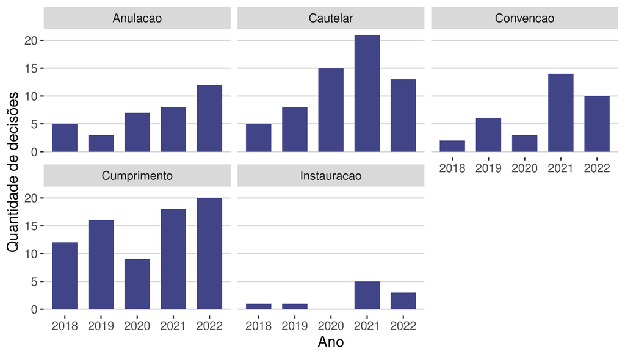

Figura 2: Quantidade de decisões por ano e categoria

A Tabela 17 mostra os resultados dos processos por categoria, **excluindo os acordos**. Nas últimas linha e coluna, são apresentadas as contagens e proporções marginais. A taxa de procedência em anulatórias (considerando casos procedentes e parcialmente procedentes e excluindo acordos do denominador) é de aproximadamente 17.7%.

Tabela 17: Resultados dos processos por categoria, excluindo acordos

[output not shown]

Com base nos dados levantados, é possível desenvolver uma análise meramente exploratória sobre a probabilidade de uma sentença arbitral ser anulada, total ou parcialmente, pela justiça. Se assumirmos, conservadoramente, que, considerando as ações que se encontram em segredo de justiça, a taxa de judicialização efetiva seria três vezes superior à taxa de 2.8% detectada na Tabela 10, chegaríamos a uma taxa de judicialização real de 8.4%. Assumindo que a taxa de procedência parcial e total das ações anulatórias permaneceria estável, no patamar geral de 17.7% indicado na Tabela 17, a probabilidade de reversão de qualquer sentença arbitral perante as varas empresariais seria a multiplicação entre essas proporções, ou seja, 1.5%.

Finalmente, a Tabela 18 mostra os tempos médios e medianos, geral e por categoria, em dias. Os processos de anulação estão em segundo lugar, com tempo mediano de quase dez meses até a sentença.

Tabela 18: Estatísticas descritivas dos tempos dos processos em dias

| Categoria | N | Média | Mediana |
| --- | --- | --- | --- |
| Instauracao | 10 | 462.7 | 301.0 |
| Anulacao | 35 | 394.7 | 291.0 |
| Convencao | 35 | 308.0 | 262.0 |
| Cumprimento | 75 | 306.5 | 251.0 |
| Cautelar | 62 | 232.1 | 193.5 |
| Total | 217 | 306.9 | 245.0 |

## Contratos de Colaboração

A Tabela 19 mostra as classes processuais mais comuns encontradas. A classe mais comum é Convenção Arbitral, que ocorre em três quartos dos casos.

Tabela 19: Classes mais comuns

| Classe | N | % |
| --- | --- | --- |
| Convenção Arbitral | 54 | 75.0% |
| Procedimento Comum Cível | 17 | 23.6% |
| Cumprimento de sentença - Lei Arbitral (Lei 9.307/1996) | 1 | 1.4% |
| Total | 72 | 100.0% |

A Tabela 20 mostra os dez assuntos processuais mais comuns encontrados. A maior parte dos casos foi classificada com assunto “Defeito, nulidade ou anulação”.

Tabela 20: Assuntos mais comuns

| Assunto | N | % |
| --- | --- | --- |
| Defeito, nulidade ou anulação | 59 | 81.9% |
| Franquia | 13 | 18.1% |
| Total | 72 | 100.0% |

A Tabela 21 mostra a contagem de processos por faixa de valores de causa. Pouco mais da metade dos casos estão na faixa entre 100 mil reais e 1 milhão de reais.

Tabela 21: Faixas de valores

| Faixa | N | % |
| --- | --- | --- |
| Até R$ 10.000 | 5 | 6.9% |
| Entre R$ 10.000 e R$ 100.000 | 13 | 18.1% |
| Entre R$ 100.000 e R$ 1 milhão | 38 | 52.8% |
| Entre R$ 1 milhão e R$ 10 milhões | 12 | 16.7% |
| R$ 10 milhões ou mais | 4 | 5.6% |
| Total | 72 | 100.0% |

A Tabela 22 mostra a contagem de processos por faixa de valores de causa nas anulatórias em contratos de colaboração. Novamente, mais da metade dos processos estão na faixa de 100 mil reais a 1 milhão de reais.

Tabela 22: Faixas de valores nas anulatórias

| Faixa | N | % |
| --- | --- | --- |
| Até R$ 10.000 | 3 | 5.0% |
| Entre R$ 10.000 e R$ 100.000 | 8 | 13.3% |
| Entre R$ 100.000 e R$ 1 milhão | 33 | 55.0% |
| Entre R$ 1 milhão e R$ 10 milhões | 12 | 20.0% |
| R$ 10 milhões ou mais | 4 | 6.7% |
| Total | 60 | 100.0% |

A Tabela 23 mostra a contagem de processos por vara. Novamente, os casos estão distribuídos de forma homogênea entre as varas empresariais. Não foram identificados casos nas RAJs para contratos de colaboração.

Tabela 23: Quantidade de processos por vara

| Vara | N | % |
| --- | --- | --- |
| 2ª Vara Empresarial e Conflitos de Arbitragem | 37 | 51.4% |
| 1ª Vara Empresarial e Conflitos de Arbitragem | 35 | 48.6% |
| Total | 72 | 100.0% |

Tabela 24: Quantidade de processos por câmara arbitral de origem

| Câmara | N | % |
| --- | --- | --- |
| Câmara Arbitral do Fórum Unimed | 58 | 96.7% |
| Conselho Arbitral da ASSOHONDA - Associação Brasileira de distribuidores Honda | 1 | 1.7% |
| Conselho Arbitral do Estado de São Paulo - CAESP | 1 | 1.7% |
| Total | 60 | 100.0% |

A Figura 3 mostra o volume de decisões ao longo do tempo, separando por categoria de caso. As anulatórias estão concentradas entre 2018 e 2020.

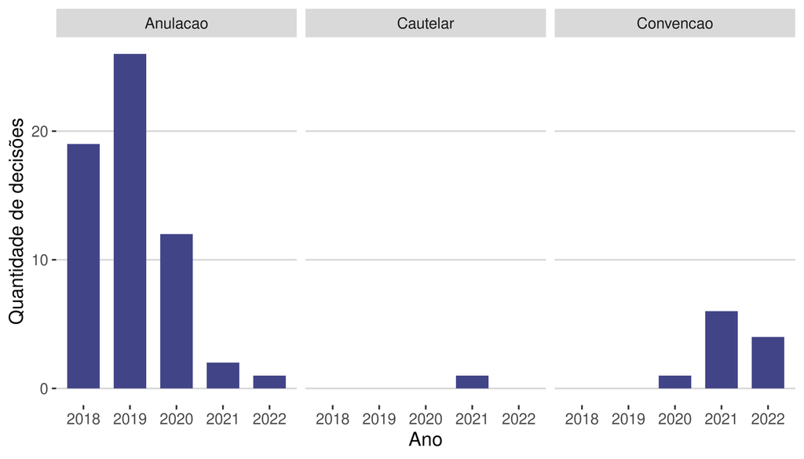

Figura 3: Quantidade de decisões por ano e categoria

A Tabela 25 mostra os resultados dos processos por categoria, **excluindo os acordos**. A taxa de procedência em anulatórias (considerando casos procedentes e parcialmente procedentes e excluindo acordos do denominador) é de aproximadamente 59.3%, significativamente maior do que foi observado na Tabela 17.

Tabela 25: Resultados dos processos por categoria, excluindo acordos

[output not shown]

Replicando a conta da seção anterior: se assumirmos, conservadoramente, que, considerando as ações que se encontram em segredo de justiça, a taxa de judicialização efetiva seria três vezes superior à taxa de 2.8% detectada na Tabela 10, chegaríamos a uma taxa de judicialização real de 8.4%. Assumindo que a taxa de procedência parcial e total das ações anulatórias em contratos de colaboração permaneceria estável, no patamar geral de 59.3% indicado na Tabela 25, a probabilidade de reversão de qualquer sentença arbitral perante as varas empresariais seria a multiplicação entre essas proporções, ou seja, 5.0%.

Finalmente, a Tabela 26 mostra os tempos médios e medianos, geral e por categoria, em dias. Os processos mais longos são os de convenção arbitral, com mediana de mais de um ano.

Tabela 26: Estatísticas descritivas dos tempos dos processos em dias

| Categoria | N | Média | Mediana |
| --- | --- | --- | --- |
| Convencao | 11 | 498.6 | 397.0 |
| Cautelar | 1 | 268.0 | 268.0 |
| Anulacao | 60 | 204.5 | 168.5 |
| Total | 72 | 250.3 | 192.0 |

## Referências

Zhao, Bo. 2017. «Web Scraping». *Encyclopedia of big data*, 1–3.

## Notas de rodapé

[^1]: Classes e assuntos são listas de tipos de processos organizadas pelo Conselho Nacional de Justiça (CNJ), através das Tabelas Processuais Unificadas (TPU), Res. 46 CNJ.
[^2]: As três primeiras varas empresariais tiveram sua criação autorizada no dia 14 de dezembro de 2017 por deliberação unânime do Órgão Especial do Tribunal de Justiça do Estado de São Paulo. Link para o parecer em https://bit.ly/parecer-varas. Acesso em 03 de maio de 2023.
[^3]: O critério de exclusão dizia respeito à pertinência do caso ao objeto da pesquisa. Assim, casos nos quais as expressões apresentavam significados distintos (falsos cognatos) foram excluídos. Por exemplo, arbitragem no sentido de arbitragem de preço e não como método de resolução de disputas. Em outros as expressões apareciam por conta de citações acidentais em precedentes e excertos de doutrina, a despeito do caso em si não tratar do tema de interesse. Por fim, um caso identificado em uma nova categoria “Carta Arbitral” (1099760-61.2021.8.26.0100) também foi desconsiderado da análise.
[^4]: Contratos Empresariais: teoria geral e aplicação, 4ª edição, 2019, p. 179-207.
[^5]: No que haveria exceção à presunção do art. 421-A do Código Civil, que determina se devem presumir “paritários e simétricos” os contratos civis e empresariais “até a presença de elementos concretos que justifiquem o afastamento dessa presunção”.
[^6]: Nesses negócios, a dependência se caracteriza “por (a) influência decisiva (b) de poder (c) de uma das partes para (d) impor circunstâncias e condições à outra, (e) que as aceita para manter o contrato e (f) se manter no mercado” (DINIZ, Gustavo Saad. Dependência econômica nos acordos verticais. Revista de Direito Privado. São Paulo: RT, 2014, v. 59, pp. 93-94). No mesmo sentido: PUGLIESI, Adriana Valéria. O abuso da dependência econômica. Revista de Direito Recuperacional e Empresa. São Paulo: RT, 2018, v. 7, p. 1 e ss.; TOMASETTI JR., Alcides. Abuso do poder econômico e abuso de poder contratual. Regime jurídico particularizado. Denunciabilidade restrita da relação contratual a tempo determinado. Contrato de fornecimento interempresarial. Monopólio estatal de sociedade fornecedora. Aumento arbitrário de lucros. Ilícitos constitucionais e de direito comum. Providências processuais corretivas. Revista dos Tribunais. São Paulo: RT, 1995, v. 715, p. 87 e ss.